# Introduction to hiddenmeta

## Install and load packages

```r
install.packages("DeclareDesign")

devtools::install_github("gerasy1987/hiddenmeta", build_vignettes = TRUE)
```

```r
library(hiddenmeta)
library(DeclareDesign)
library(knitr)
```

## Step 1. Provide study design features

```r
## STUDY 1
study_1 <-
  list(
    pop =
      list(
        handler = get_study_population,

        # network structure setup
        network_handler = sim_block_network,
        network_handler_args =
          list(N = 1000, K = 2, prev_K = c(known = .3, hidden = .1), rho_K = 0,
               p_edge_within = list(known = c(0.1, 0.3), hidden = c(0.1, 0.3)),
               p_edge_between = list(known = 0.1, hidden = 0.1),
               directed = FALSE),

        # groups
        group_names = c("known", "hidden"),

        # probability of visibility (show-up) for each group
        p_visible = list(known = 1, hidden = 1),

        # probability of service utilization in hidden population
        # for service multiplier
        add_groups =
          list(service_use = "rbinom(n(), 1, 0.25)",
         "purrr::map_df(hidden, ~ sapply( `names<-`(rep(0, times = 10), paste0('loc_', 1:10)), function(add) rbinom(length(.x), 1, 0.1 + .x * add)))",
         known_2 = 0.3, known_3 = 0.3)
      ),
    sample =
      list(
        rds = list(handler = sample_rds,
                   # RDS parameters
                   sampling_variable = "rds",
                   hidden_var = "hidden", # default
                   n_seed = 20,
                   n_coupons = 3,
                   add_seeds = 3,
                   target_type = "sample",
                   target_n_rds = 60),
        tls = list(handler = sample_tls,
                   sampling_variable = "tls",
                   # TLS sampling parameters
                   target_n_clusters = 4,
                   target_n_tls = 180,
                   cluster = paste0("loc_", 1:10)),
        pps = list(handler = sample_pps,
                   sampling_variable = "pps",
                   # prop sampling parameters
                   sampling_frame = NULL,
                   strata = NULL,
                   cluster = NULL,
                   target_n_pps = 200)
      ),
    inquiries = list(handler = get_study_estimands,
                     known_pattern = "^known$",
                     hidden_var = "hidden"),
    estimators =
      list(
        rds =
          list(sspse = list(handler = get_study_est_sspse,
                            prior_mean = 100,
                            mcmc_params = list(interval = 5, burnin = 2000, samplesize = 500),
                            total = 1000,
                            rds_prefix = "rds",
                            label = "rds_sspse"),
               chords = list(handler = get_study_est_chords,
                             type = "mle",
                             seed_condition = "rds_from == -999",
                             n_boot = 100,
                             rds_prefix = "rds",
                             label = "rds_chords"),
               multiplier = list(handler = get_study_est_multiplier,
                                 service_var = "service_use",
                                 seed_condition = "rds_from == -999",
                                 n_boot = 100,
                                 rds_prefix = "rds",
                                 label = "rds_multi")),
        tls =
          list(ht = list(handler = get_study_est_ht,
                         weight_var = "tls_weight",
                         prefix = "tls",
                         label = "tls_ht"),
               nsum = list(handler = get_study_est_nsum,
                           known = c("known", "known_2", "known_3"),
                           hidden = "hidden_visible_out",
                           survey_design = ~ tls_cluster,
                           n_boot = 100,
                           prefix = "tls",
                           label = "tls_nsum"),
               recap = list(handler = get_study_est_recapture,
                            capture_parse =
                              "strsplit(x = unique(na.omit(tls_locs_sampled)), split = ';')[[1]]",
                            sample_condition = "tls == 1",
                            model = "Mt",
                            hidden_variable = "hidden",
                            label = "tls_recap")),
        pps =
          list(ht = list(handler = get_study_est_ht,
                         prefix = "pps",
                         label = "pps_ht"),
               nsum = list(handler = get_study_est_nsum,
                           known = c("known", "known_2", "known_3"),
                           hidden = "hidden_visible_out",
                           survey_design = ~ pps_cluster + strata(pps_strata),
                           n_boot = 100,
                           prefix = "pps",
                           label = "pps_nsum")),
        all =
          list(recap1 = list(handler = get_study_est_recapture,
                             capture_vars = c("rds", "pps"),
                             model = "Mt",
                             hidden_variable = "hidden",
                             label = "rds_pps_recap"),
               recap2 = list(handler = get_study_est_recapture,
                             capture_vars = c("rds"),
                             capture_parse =
                              "strsplit(x = unique(na.omit(tls_locs_sampled)), split = ';')[[1]]",
                             model = "Mt",
                             hidden_variable = "hidden",
                             label = "rds_tls_recap"))
      )
  )
```

## Step 2. Declare study population

```r
study_population <-
  eval(as.call(c(list(declare_population), study_1$pop)))

set.seed(872312)
example_pop <- study_population()

example_pop %>%
  dplyr::sample_n(n()) %>%
  DT::datatable(options = list(scrollX = TRUE, pageLength = 15))
```

|  | name | type | known | hidden | links | service_use | loc_1 | loc_2 | loc_3 | loc_4 | loc_5 | loc_6 | loc_7 | loc_8 | loc_9 | loc_10 | known_2 | known_3 | n_visible_out | known_visible_out | hidden_visible_out | type_00_visible_out | type_01_visible_out | type_10_visible_out | type_11_visible_out | service_use_visible_out | loc_1_visible_out | loc_2_visible_out | loc_3_visible_out | … |
| --- | --- | --- | --- | --- | --- | --- | --- | --- | --- | --- | --- | --- | --- | --- | --- | --- | --- | --- | --- | --- | --- | --- | --- | --- | --- | --- | --- | --- | --- | --- |
| 1 | 583 | 00 | 0 | 0 | 215;310;628;917;918 | 0 | 0 | 0 | 0 | 0 | 0 | 0 | 0 | 0 | 0 | 0 | 1 | 1 | 5 | 1 | 2 | 2 | 2 | 1 | 0 | 1 | 1 | 1 | 0 | … |
| 2 | 140 | 00 | 0 | 0 | 19;53;437;571;580;877;912;920;947 | 1 | 0 | 0 | 0 | 0 | 0 | 0 | 0 | 0 | 0 | 0 | 0 | 1 | 9 | 1 | 3 | 5 | 3 | 1 | 0 | 3 | 0 | 0 | 1 | … |
| 3 | 670 | 10 | 1 | 0 | 1;90;103;136;185;227;255;272;290;539;627;686;687;728;773;793;809;813;837;865;884;919;989 | 0 | 0 | 0 | 0 | 0 | 0 | 0 | 0 | 0 | 1 | 0 | 0 | 1 | 23 | 12 | 2 | 10 | 1 | 11 | 1 | 4 | 3 | 1 | 4 | … |
| 4 | 218 | 00 | 0 | 0 | 102;280;854;988;996 | 1 | 0 | 0 | 0 | 0 | 0 | 0 | 0 | 0 | 0 | 0 | 1 | 0 | 5 | 3 | 2 | 2 | 0 | 1 | 2 | 1 | 0 | 2 | 0 | … |
| 5 | 97 | 00 | 0 | 0 | 139;198;202;261;375;445;501;507;608;794;955 | 0 | 0 | 0 | 1 | 0 | 0 | 0 | 0 | 0 | 0 | 0 | 1 | 0 | 11 | 1 | 1 | 9 | 1 | 1 | 0 | 3 | 1 | 0 | 5 | … |
| 6 | 99 | 00 | 0 | 0 | 16;95;244;280;291;316;559;633;666;771;911 | 0 | 0 | 1 | 0 | 0 | 0 | 0 | 0 | 0 | 1 | 1 | 1 | 0 | 11 | 3 | 1 | 7 | 1 | 3 | 0 | 3 | 1 | 1 | 4 | … |
| 7 | 116 | 00 | 0 | 0 | 62;88;127;290;674;736;775 | 1 | 0 | 0 | 0 | 0 | 0 | 0 | 0 | 0 | 1 | 0 | 1 | 0 | 7 | 3 | 0 | 4 | 0 | 3 | 0 | 1 | 0 | 0 | 0 | … |
| 8 | 899 | 10 | 1 | 0 | 168;191;401;466;526;689;698;699;723;806;892;900;961 | 1 | 0 | 0 | 1 | 0 | 0 | 0 | 0 | 0 | 1 | 0 | 0 | 0 | 13 | 7 | 1 | 5 | 1 | 7 | 0 | 4 | 0 | 1 | 1 | … |
| 9 | 753 | 10 | 1 | 0 | 40;288;411;422;449;469;493;506;632;643;653;683;724;747;749;754;789;801;818;913;931;976;989 | 1 | 0 | 0 | 0 | 0 | 0 | 0 | 0 | 0 | 0 | 0 | 0 | 0 | 23 | 13 | 4 | 8 | 2 | 11 | 2 | 8 | 1 | 4 | 1 | … |
| 10 | 845 | 10 | 1 | 0 | 304;448;589;674;686;720;738;742;749;775;778;783;787;811;976 | 1 | 0 | 0 | 0 | 0 | 0 | 0 | 0 | 0 | 0 | 0 | 0 | 0 | 15 | 12 | 1 | 3 | 0 | 11 | 1 | 2 | 1 | 1 | 2 | … |

[output cut: 990 more lines]

### Show the network

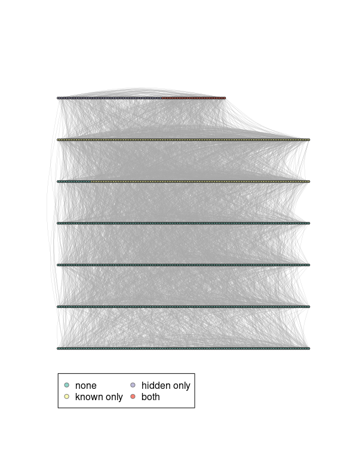

```r
g <-
  example_pop %$% {
    hiddenmeta:::retrieve_graph(links) %>%
      igraph::set_vertex_attr("name", value = name) %>%
      igraph::set_vertex_attr("type", value = type)
  }

igraph::V(g)$color <-
  plyr::mapvalues(igraph::V(g)$type,
                  from = unique(igraph::V(g)$type),
                  to = grDevices::palette.colors(n = length(unique(igraph::V(g)$type)),
                                                 palette = "Set 3"))

plot(g,
     # layout = igraph::layout_on_grid(g, dim = 2, width = 100),
     layout = igraph::layout_on_grid(g, dim = 2, width = 150),
     vertex.size = 1.5, vertex.dist = 4, vertex.label = NA, edge.width = .2,
     edge.arrow.size = .2, edge.curved = .2)

legend(x = -1, y = -1.2,
       legend = c("none", "known only", "hidden only", "both"),
       pt.bg = grDevices::palette.colors(n = length(unique(igraph::V(g)$type)), palette = "Set 3"),
       pch = 21, col = "#777777", pt.cex = 1, cex = 1, bty = "o", ncol = 2)
```

## Step 3. Declare all relevant study sampling procedures

The sampling procedures are additive in a sense that each procedure appends several columns relevant to the sampling procedure and particular draw based on population simulation, but does not change the study population data frame (unless you specify `drop_nonsampled = TRUE`).

```r
study_sample_rds <-
  eval(as.call(c(list(declare_sampling), study_1$sample$rds)))

set.seed(872312)
draw_data(study_population + study_sample_rds) %>%
  dplyr::sample_n(n()) %>%
  DT::datatable(options = list(scrollX = TRUE, pageLength = 15))
```

|  | name | type | known | hidden | links | service_use | loc_1 | loc_2 | loc_3 | loc_4 | loc_5 | loc_6 | loc_7 | loc_8 | loc_9 | loc_10 | known_2 | known_3 | n_visible_out | known_visible_out | hidden_visible_out | type_00_visible_out | type_01_visible_out | type_10_visible_out | type_11_visible_out | service_use_visible_out | loc_1_visible_out | loc_2_visible_out | loc_3_visible_out | … |
| --- | --- | --- | --- | --- | --- | --- | --- | --- | --- | --- | --- | --- | --- | --- | --- | --- | --- | --- | --- | --- | --- | --- | --- | --- | --- | --- | --- | --- | --- | --- |
| 1 | 6 | 00 | 0 | 0 | 207;243;309;402;505;638;773;774;861;881 | 0 | 0 | 0 | 0 | 0 | 0 | 0 | 0 | 1 | 0 | 0 | 0 | 0 | 10 | 5 | 0 | 5 | 0 | 5 | 0 | 2 | 2 | 1 | 0 | … |
| 2 | 100 | 00 | 0 | 0 | 253;364;573;711;720;943 | 1 | 0 | 0 | 0 | 0 | 0 | 1 | 0 | 0 | 0 | 1 | 0 | 0 | 6 | 2 | 1 | 3 | 1 | 2 | 0 | 0 | 0 | 0 | 0 | … |
| 3 | 502 | 00 | 0 | 0 | 59;183;198;288;319;574;643;878;926 | 0 | 0 | 0 | 0 | 0 | 0 | 0 | 0 | 0 | 0 | 0 | 1 | 0 | 9 | 2 | 1 | 6 | 1 | 2 | 0 | 3 | 1 | 0 | 4 | … |
| 4 | 741 | 10 | 1 | 0 | 178;256;335;404;431;818;822;842;920 | 0 | 0 | 0 | 0 | 0 | 0 | 0 | 0 | 1 | 0 | 1 | 1 | 0 | 9 | 3 | 1 | 5 | 1 | 3 | 0 | 2 | 1 | 1 | 1 | … |
| 5 | 971 | 11 | 1 | 1 | 16;46;75;154;175;219;282;285;468;542;560;613;622;634;667;680;730;744;756;758;761;764;769;774;794;800;821;836;916;947;977;979 | 0 | 0 | 1 | 0 | 0 | 0 | 0 | 0 | 0 | 0 | 0 | 0 | 0 | 32 | 18 | 4 | 12 | 2 | 16 | 2 | 9 | 5 | 2 | 3 | … |
| 6 | 102 | 00 | 0 | 0 | 56;63;78;190;218;264;280;306;328;392;465;471;482;541;545;547;787;827;852 | 0 | 0 | 0 | 0 | 0 | 0 | 0 | 0 | 1 | 0 | 0 | 0 | 0 | 19 | 3 | 0 | 16 | 0 | 3 | 0 | 5 | 1 | 2 | 0 | … |
| 7 | 204 | 00 | 0 | 0 | 34;85;219;268;306;312;339;345;478;581;734;768;812;829 | 0 | 0 | 0 | 0 | 0 | 0 | 0 | 0 | 0 | 0 | 0 | 1 | 0 | 14 | 4 | 0 | 10 | 0 | 4 | 0 | 4 | 1 | 1 | 1 | … |
| 8 | 764 | 10 | 1 | 0 | 215;250;633;674;682;716;717;724;776;859;894;971 | 1 | 0 | 0 | 0 | 1 | 0 | 0 | 1 | 0 | 0 | 1 | 1 | 0 | 12 | 10 | 1 | 2 | 0 | 9 | 1 | 2 | 2 | 1 | 0 | … |
| 9 | 193 | 00 | 0 | 0 | 10;20;208;413;438;533;559;598;739;759 | 1 | 0 | 1 | 0 | 0 | 0 | 0 | 0 | 0 | 1 | 0 | 0 | 0 | 10 | 2 | 0 | 8 | 0 | 2 | 0 | 4 | 1 | 1 | 2 | … |
| 10 | 523 | 00 | 0 | 0 | 1;176;205;315;433;537;557;626;751;883;993 | 1 | 0 | 0 | 0 | 0 | 0 | 0 | 0 | 0 | 0 | 0 | 0 | 0 | 11 | 4 | 1 | 7 | 0 | 3 | 1 | 0 | 0 | 2 | 2 | … |

[output cut: 990 more lines]

```r
study_sample_pps <-
  eval(as.call(c(list(declare_sampling), study_1$sample$pps)))

set.seed(872312)
draw_data(study_population + study_sample_rds + study_sample_pps) %>%
  dplyr::sample_n(n()) %>%
  DT::datatable(options = list(scrollX = TRUE, pageLength = 15))
```

|  | name | type | known | hidden | links | service_use | loc_1 | loc_2 | loc_3 | loc_4 | loc_5 | loc_6 | loc_7 | loc_8 | loc_9 | loc_10 | known_2 | known_3 | n_visible_out | known_visible_out | hidden_visible_out | type_00_visible_out | type_01_visible_out | type_10_visible_out | type_11_visible_out | service_use_visible_out | loc_1_visible_out | loc_2_visible_out | loc_3_visible_out | … |
| --- | --- | --- | --- | --- | --- | --- | --- | --- | --- | --- | --- | --- | --- | --- | --- | --- | --- | --- | --- | --- | --- | --- | --- | --- | --- | --- | --- | --- | --- | --- |
| 1 | 171 | 00 | 0 | 0 | 216;217;539;555;818;825;836;969;972 | 0 | 0 | 0 | 0 | 0 | 0 | 0 | 0 | 0 | 0 | 0 | 0 | 1 | 9 | 5 | 2 | 4 | 0 | 3 | 2 | 2 | 0 | 3 | 2 | … |
| 2 | 214 | 00 | 0 | 0 | 29;114;123;258;298;393;431;487;637;640;668;674;892;949;952 | 0 | 0 | 1 | 0 | 0 | 0 | 0 | 0 | 0 | 0 | 0 | 1 | 0 | 15 | 5 | 2 | 8 | 2 | 5 | 0 | 1 | 1 | 1 | 2 | … |
| 3 | 589 | 00 | 0 | 0 | 36;845;858 | 0 | 0 | 0 | 0 | 0 | 0 | 0 | 0 | 0 | 0 | 0 | 1 | 0 | 3 | 2 | 0 | 1 | 0 | 2 | 0 | 2 | 0 | 0 | 0 | … |
| 4 | 561 | 00 | 0 | 0 | 10;187;295;296;409;411;445;554;608;743;808;811;889 | 0 | 0 | 0 | 0 | 0 | 0 | 1 | 0 | 1 | 1 | 1 | 0 | 0 | 13 | 4 | 0 | 9 | 0 | 4 | 0 | 2 | 0 | 1 | 1 | … |
| 5 | 909 | 01 | 0 | 1 | 60;75;95;142;177;491;500;557;598;723;781;861;953;1000 | 0 | 0 | 0 | 0 | 1 | 0 | 1 | 0 | 0 | 0 | 0 | 0 | 0 | 14 | 4 | 2 | 9 | 1 | 3 | 1 | 4 | 1 | 2 | 1 | … |
| 6 | 682 | 10 | 1 | 0 | 55;157;167;227;338;373;402;526;699;739;755;764;774;846;882;953;956;966;973 | 1 | 0 | 0 | 0 | 0 | 0 | 0 | 0 | 0 | 0 | 1 | 0 | 0 | 19 | 9 | 4 | 8 | 2 | 7 | 2 | 6 | 3 | 1 | 3 | … |
| 7 | 421 | 00 | 0 | 0 | 83;268;445;491;528;572;750;814;870;886;952 | 1 | 0 | 0 | 0 | 0 | 0 | 1 | 0 | 0 | 0 | 0 | 0 | 1 | 11 | 4 | 1 | 6 | 1 | 4 | 0 | 5 | 1 | 0 | 0 | … |
| 8 | 347 | 00 | 0 | 0 | 315;337;353;376;383;417;419;505;612;701;835 | 0 | 0 | 0 | 0 | 0 | 0 | 1 | 0 | 0 | 1 | 0 | 0 | 1 | 11 | 2 | 0 | 9 | 0 | 2 | 0 | 3 | 0 | 1 | 2 | … |
| 9 | 595 | 00 | 0 | 0 | 43;48;50;126;270;579;818 | 1 | 0 | 0 | 0 | 0 | 0 | 0 | 0 | 0 | 0 | 0 | 0 | 1 | 7 | 1 | 0 | 6 | 0 | 1 | 0 | 3 | 3 | 1 | 2 | … |
| 10 | 847 | 10 | 1 | 0 | 35;77;136;221;380;419;439;445;598;712;719;762;783;793;803;851;857;868;930;996 | 0 | 0 | 0 | 0 | 0 | 0 | 0 | 0 | 0 | 0 | 1 | 1 | 0 | 20 | 10 | 2 | 9 | 1 | 9 | 1 | 6 | 5 | 2 | 3 | … |

[output cut: 990 more lines]

```r
study_sample_tls <-
  eval(as.call(c(list(declare_sampling), study_1$sample$tls)))

set.seed(872312)
draw_data(study_population +
            study_sample_rds + study_sample_pps + study_sample_tls) %>%
  dplyr::sample_n(n()) %>%
  DT::datatable(options = list(scrollX = TRUE, pageLength = 15))
```

|  | name | type | known | hidden | links | service_use | loc_1 | loc_2 | loc_3 | loc_4 | loc_5 | loc_6 | loc_7 | loc_8 | loc_9 | loc_10 | known_2 | known_3 | n_visible_out | known_visible_out | hidden_visible_out | type_00_visible_out | type_01_visible_out | type_10_visible_out | type_11_visible_out | service_use_visible_out | loc_1_visible_out | loc_2_visible_out | loc_3_visible_out | … |
| --- | --- | --- | --- | --- | --- | --- | --- | --- | --- | --- | --- | --- | --- | --- | --- | --- | --- | --- | --- | --- | --- | --- | --- | --- | --- | --- | --- | --- | --- | --- |
| 1 | 744 | 10 | 1 | 0 | 38;81;95;112;132;551;650;692;767;774;824;971;991 | 0 | 0 | 0 | 0 | 0 | 0 | 0 | 0 | 0 | 0 | 0 | 0 | 0 | 13 | 7 | 2 | 6 | 0 | 5 | 2 | 2 | 3 | 3 | 1 | … |
| 2 | 574 | 00 | 0 | 0 | 93;120;199;248;268;395;414;502;505;902;942 | 0 | 0 | 0 | 0 | 0 | 0 | 0 | 0 | 0 | 0 | 1 | 0 | 0 | 11 | 0 | 2 | 9 | 2 | 0 | 0 | 2 | 2 | 1 | 0 | … |
| 3 | 278 | 00 | 0 | 0 | 182;226;331;456;632;694;713;805;808;815;818;858;873 | 1 | 0 | 0 | 0 | 0 | 0 | 0 | 0 | 0 | 0 | 1 | 1 | 0 | 13 | 9 | 0 | 4 | 0 | 9 | 0 | 5 | 1 | 1 | 1 | … |
| 4 | 798 | 10 | 1 | 0 | 10;408;441;667;707;716;729;732;733;869;879;888;968 | 0 | 0 | 0 | 0 | 0 | 0 | 0 | 0 | 0 | 0 | 0 | 0 | 0 | 13 | 10 | 1 | 3 | 0 | 9 | 1 | 1 | 1 | 0 | 1 | … |
| 5 | 318 | 00 | 0 | 0 | 65;98;133;172;433;549;590;683;780;858;915 | 0 | 0 | 0 | 0 | 0 | 0 | 0 | 0 | 0 | 0 | 0 | 0 | 1 | 11 | 3 | 1 | 7 | 1 | 3 | 0 | 5 | 1 | 3 | 1 | … |
| 6 | 526 | 00 | 0 | 0 | 181;267;286;476;677;682;813;898;899 | 0 | 0 | 0 | 0 | 0 | 0 | 0 | 0 | 0 | 0 | 0 | 0 | 1 | 9 | 5 | 0 | 4 | 0 | 5 | 0 | 5 | 0 | 0 | 1 | … |
| 7 | 512 | 00 | 0 | 0 | 47;405;721;906;936;969 | 0 | 1 | 0 | 0 | 0 | 0 | 0 | 0 | 0 | 0 | 0 | 0 | 0 | 6 | 2 | 3 | 2 | 2 | 1 | 1 | 1 | 1 | 0 | 0 | … |
| 8 | 682 | 10 | 1 | 0 | 55;157;167;227;338;373;402;526;699;739;755;764;774;846;882;953;956;966;973 | 1 | 0 | 0 | 0 | 0 | 0 | 0 | 0 | 0 | 0 | 1 | 0 | 0 | 19 | 9 | 4 | 8 | 2 | 7 | 2 | 6 | 3 | 1 | 3 | … |
| 9 | 556 | 00 | 0 | 0 | 362;413;511;658;698;772;872 | 1 | 0 | 0 | 0 | 0 | 0 | 1 | 0 | 0 | 0 | 0 | 1 | 0 | 7 | 4 | 0 | 3 | 0 | 4 | 0 | 2 | 0 | 0 | 1 | … |
| 10 | 656 | 10 | 1 | 0 | 12;464;468;694;700;714;727;733;749;806;811;823;875 | 1 | 0 | 0 | 0 | 0 | 0 | 0 | 1 | 0 | 0 | 0 | 1 | 0 | 13 | 10 | 0 | 3 | 0 | 10 | 0 | 3 | 0 | 1 | 1 | … |

[output cut: 990 more lines]

## Step 4. Declare study level estimands

```r
study_estimands <-
  eval(as.call(c(list(declare_inquiry), study_1$inquiries)))

set.seed(872312)
draw_estimands(study_population +
                 # study_sample_rds + study_sample_pps + study_sample_tls +
                 study_estimands) %>%
  kable(digits = 2)
```

| inquiry | estimand |
| --- | --- |
| known_size | 318.00 |
| hidden_size | 100.00 |
| known_prev | 0.32 |
| hidden_prev | 0.10 |
| hidden_size_in_known | 38.00 |
| hidden_prev_in_known | 0.12 |

## Step 5. Declare estimators used in the study

```r
est_sspse <-
  eval(as.call(c(list(declare_estimator), study_1$estimators$rds$sspse)))
est_chords <-
  eval(as.call(c(list(declare_estimator), study_1$estimators$rds$chords)))
est_multi <-
  eval(as.call(c(list(declare_estimator), study_1$estimators$rds$multiplier)))

est_ht_pps <-
  eval(as.call(c(list(declare_estimator), study_1$estimators$pps$ht)))
est_nsum_pps <-
  eval(as.call(c(list(declare_estimator), study_1$estimators$pps$nsum)))

est_ht_tls <-
  eval(as.call(c(list(declare_estimator), study_1$estimators$tls$ht)))
est_nsum_tls <-
  eval(as.call(c(list(declare_estimator), study_1$estimators$tls$nsum)))
est_recap_tls <-
  eval(as.call(c(list(declare_estimator), study_1$estimators$tls$recap)))

est_recap_rds_pps <-
  eval(as.call(c(list(declare_estimator), study_1$estimators$all$recap1)))
est_recap_rds_tls <-
  eval(as.call(c(list(declare_estimator), study_1$estimators$all$recap2)))

set.seed(872312)
draw_estimates(study_population +
                 study_sample_rds + study_sample_pps + study_sample_tls +
                 study_estimands +
                 est_sspse + est_chords + est_multi +
                 est_nsum_pps + est_ht_pps +
                 est_nsum_tls + est_ht_tls + est_recap_tls +
                 est_recap_rds_pps + est_recap_rds_tls) %>%
  kable(digits = 2)
```

| estimator | estimate | se | inquiry |
| --- | --- | --- | --- |
| hidden_size_rds_sspse | 104.00 | 26.30 | hidden_size |
| hidden_size_rds_chords | 37.00 | 24.05 | hidden_size |
| hidden_size_rds_multi | 104.00 | 29.33 | hidden_size |
| hidden_size_pps_nsum | 101.82 | 6.32 | hidden_size |
| hidden_size_pps_ht | 85.00 | 19.85 | hidden_size |
| hidden_prev_pps_ht | 0.09 | 0.02 | hidden_prev |
| hidden_size_tls_nsum | 106.11 | 2.37 | hidden_size |
| hidden_size_tls_ht | 4.03 | 0.85 | hidden_size |
| hidden_prev_tls_ht | 0.00 | 0.00 | hidden_prev |
| hidden_size_tls_recap | 51.07 | 21.46 | hidden_size |
| hidden_size_rds_pps_recap | 98.82 | 16.27 | hidden_size |
| hidden_size_rds_tls_recap | 98.83 | 9.77 | hidden_size |

## Step 6. Declare full study

```r
study1 <-
  study_population +
  study_sample_rds + study_sample_pps + study_sample_tls +
  study_estimands +
  est_sspse + est_chords + est_multi +
  est_nsum_pps + est_ht_pps +
  est_nsum_tls + est_ht_tls + est_recap_tls +
  est_recap_rds_pps + est_recap_rds_tls

# # can draw one of the samples
# study1$study_sample_rds(study1$study_population())
#
# # can draw full data
# study1_data <- draw_data(study1)
#
# # can draw estimands
# study1$inquiry(study1_data)
#
# # can draw any of the estimators
# study1$rds_sspse(study1_data)
# study1$pps_ht(study1_data)
# study1$rds_pps_recap(study1_data)
```

## Step 7. Diagnose study design

```r
requireNamespace(c("doParallel", "parallel"))
doParallel::registerDoParallel(cores = 7)

set.seed(872312)
study1_simulations <-
  plyr::llply(
    as.list(1:100),
    .fun = function(x) {
      base::suppressWarnings(
        DeclareDesign::simulate_design(study1, sims = 1) %>%
          dplyr::mutate(
            sim_ID = x
          )
      )
    },
    .parallel = TRUE
  ) %>%
  dplyr::bind_rows()

saveRDS(study1_simulations, "vignettes/study1_sim.rds")
```

```r
study_diagnosands <-
 declare_diagnosands(
    mean_estimand = mean(estimand),
    mean_estimate = mean(estimate),
    sd_estimate = sd(estimate),
    mean_se = mean(se),
    bias = mean(estimate - estimand),
    rmse = sqrt(mean((estimate - estimand) ^ 2))
  )

study1_simulations <- readRDS(here::here("vignettes/study1_sim.rds"))

diagnose_design(simulations_df = study1_simulations,
                diagnosands = study_diagnosands) %>%
  reshape_diagnosis %>% select(-'Design') %>%
  kable()
```

| Inquiry | Estimator | N Sims | Mean Estimand | Mean Estimate | SD Estimate | Mean Se | Bias | RMSE |
| --- | --- | --- | --- | --- | --- | --- | --- | --- |
| hidden_prev | hidden_prev_pps_ht | 100 | 0.10 | 0.11 | 0.03 | 0.02 | 0.01 | 0.03 |
|  |  |  | (0.00) | (0.00) | (0.00) | (0.00) | (0.00) | (0.00) |
| hidden_prev | hidden_prev_tls_ht | 100 | 0.10 | 0.00 | 0.00 | 0.00 | -0.09 | 0.09 |
|  |  |  | (0.00) | (0.00) | (0.00) | (0.00) | (0.00) | (0.00) |
| hidden_prev_in_known | NA | 100 | 0.09 | NA | NA | NA | NA | NA |
|  |  |  | (0.00) | NA | NA | NA | NA | NA |
| hidden_size | hidden_size_pps_ht | 100 | 95.17 | 106.50 | 28.15 | 21.77 | 11.33 | 27.10 |
|  |  |  | (0.60) | (3.01) | (2.28) | (0.29) | (2.64) | (2.32) |
| hidden_size | hidden_size_pps_nsum | 100 | 95.17 | 99.37 | 12.57 | 6.71 | 4.20 | 9.68 |
|  |  |  | (0.60) | (1.38) | (1.06) | (0.09) | (0.97) | (0.81) |
| hidden_size | hidden_size_rds_chords | 100 | 95.17 | 77.37 | 38.38 | 35.41 | -17.80 | 43.65 |
|  |  |  | (0.60) | (3.95) | (2.42) | (0.88) | (4.10) | (2.17) |
| hidden_size | hidden_size_rds_multi | 100 | 95.17 | 91.42 | 13.31 | 23.72 | -3.75 | 13.59 |
|  |  |  | (0.60) | (1.23) | (1.01) | (0.90) | (1.17) | (0.97) |
| hidden_size | hidden_size_rds_pps_recap | 100 | 95.17 | 101.07 | 19.64 | 15.32 | 5.90 | 17.13 |
|  |  |  | (0.60) | (1.89) | (1.55) | (0.55) | (1.55) | (1.38) |
| hidden_size | hidden_size_rds_sspse | 100 | 95.17 | 159.71 | 32.63 | 92.65 | 64.54 | 72.41 |
|  |  |  | (0.60) | (3.42) | (4.82) | (3.97) | (3.48) | (4.91) |
| hidden_size | hidden_size_rds_tls_recap | 100 | 95.17 | 98.38 | 11.34 | 10.23 | 3.21 | 11.04 |
|  |  |  | (0.60) | (1.12) | (0.76) | (0.26) | (1.03) | (0.91) |
| hidden_size | hidden_size_tls_ht | 100 | 95.17 | 3.43 | 1.15 | 0.90 | -91.74 | 91.91 |
|  |  |  | (0.60) | (0.11) | (0.06) | (0.02) | (0.56) | (0.57) |
| hidden_size | hidden_size_tls_nsum | 100 | 95.17 | 98.73 | 14.26 | 7.60 | 3.56 | 11.03 |
|  |  |  | (0.60) | (1.52) | (1.18) | (0.33) | (1.12) | (0.94) |
| hidden_size | hidden_size_tls_recap | 100 | 95.17 | 33.72 | 15.29 | 13.19 | -61.45 | 63.34 |
|  |  |  | (0.60) | (1.58) | (2.56) | (1.35) | (1.61) | (1.27) |
| hidden_size_in_known | NA | 100 | 27.35 | NA | NA | NA | NA | NA |
|  |  |  | (0.40) | NA | NA | NA | NA | NA |
| known_prev | NA | 100 | 0.30 | NA | NA | NA | NA | NA |
|  |  |  | (0.00) | NA | NA | NA | NA | NA |
| known_size | NA | 100 | 301.35 | NA | NA | NA | NA | NA |
|  |  |  | (0.96) | NA | NA | NA | NA | NA |

## Diagnosis of multiple studies

### Additional study designs

```r
study_2 <-
  list(
    pop =
      list(
        handler = get_study_population,
        network_handler = sim_block_network,
        network_handler_args =
          list(N = 5000, K = 3,
               prev_K = c(frame = .5, known = .2, hidden = .1),
               rho_K = c(.05, .05, .05),
               p_edge_within = list(frame = c(0.05, 0.05),
                                    known = c(0.1, 0.05),
                                    hidden = c(0.2, 0.9)),
               p_edge_between = list(frame = 0.05,
                                     known = 0.1,
                                     hidden = 0.01),
               directed = FALSE),

        group_names = c("frame", "known", "hidden"),

        # probability of visibility (show-up) for each group
        p_visible = list(frame = 1, known = 1, hidden = .6),

        # probability of service utilization in hidden population
        # for service multiplier

        add_groups =
          list(service_use = "rbinom(n(), 1, 0.25 + hidden * 0.3)",
               "purrr::map_df(hidden, ~ sapply( `names<-`(runif(10, 0.05,.3), paste0('loc_', 1:10)), function(add) rbinom(length(.x), 1, 0.1 + .x * add)))",
               known_2 = 0.1, known_3 = 0.2)
      ),
    sample =
      list(
        rds = list(handler = sample_rds,
                   # RDS parameters
                   sampling_variable = "rds",
                   hidden_var = "hidden",
                   n_seed = 100,
                   n_coupons = 3,
                   target_type = "waves",
                   target_n_rds = 2),
        tls = list(handler = sample_tls,
                   sampling_variable = "tls",
                   # TLS sampling parameters
                   target_n_clusters = 4,
                   target_n_tls = 300,
                   cluster = paste0("loc_", 1:8)),
        pps = list(handler = sample_pps,
                   sampling_variable = "pps",
                   # prop sampling parameters
                   sampling_frame = "frame",
                   strata = NULL,
                   cluster = NULL,
                   target_n_pps = 800)
      ),
    inquiries = list(handler = get_study_estimands,
                     known_pattern = "^known$|^frame$",
                     hidden_var = "hidden"),
    estimators =
      list(
        rds =
          list(sspse = list(handler = get_study_est_sspse,
                            label = "rds_sspse",
                            prior_mean = 450,
                            mcmc_params = list(interval = 5, burnin = 2000, samplesize = 500),
                            total = 5000,
                            rds_prefix = "rds"),
               chords = list(handler = get_study_est_chords,
                             type = "mle",
                             label = "rds_chords",
                             seed_condition = "rds_from == -999",
                             n_boot = 100,
                             rds_prefix = "rds"),
               multiplier = list(handler = get_study_est_multiplier,
                                 service_var = "service_use",
                                 seed_condition = "rds_from == -999",
                                 n_boot = 100,
                                 rds_prefix = "rds",
                                 label = "rds_multi")),
        tls =
          list(ht = list(handler = get_study_est_ht,
                         weight_var = "tls_weight",
                         prefix = "tls",
                         label = "tls_ht"),
               nsum = list(handler = get_study_est_nsum,
                           known = c("known", "frame"),
                           hidden = "hidden_visible_out",
                           survey_design = ~ tls_cluster,
                           n_boot = 100,
                           prefix = "tls",
                           label = "tls_nsum"),
               recap = list(handler = get_study_est_recapture,
                            capture_vars = paste0("loc_", 1:8),
                            sample_condition = "tls == 1",
                            model = "Mt",
                            hidden_variable = "hidden",
                            label = "tls_recap")),
        pps =
          list(
            ht = list(handler = get_study_est_ht,
                      label = "pps_ht"),
            nsum = list(handler = get_study_est_nsum,
                        known = c("frame", "known"),
                        hidden = "hidden_visible_out",
                        survey_design = ~ pps_cluster + strata(pps_strata),
                        n_boot = 100,
                        label = "pps_nsum")),
        all =
          list(recap1 = list(handler = get_study_est_recapture,
                             capture_vars = c("rds", "pps"),
                             model = "Mt",
                             hidden_variable = "hidden",
                             label = "rds_pps_recap"),
               recap2 = list(handler = get_study_est_recapture,
                             capture_vars = c("rds", paste0("loc_", 1:8)),
                             model = "Mt",
                             hidden_variable = "hidden",
                             label = "rds_tls_recap"))
      )
  )

study_3 <-
  list(
    pop =
      list(
        handler = get_study_population,

        # network structure setup
        network_handler = sim_block_network,
        network_handler_args =
          list(N = 2000, K = 2, prev_K = c(known = .3, hidden = .1), rho_K = .3,
               p_edge_within = list(known = c(0.05, 0.1), hidden = c(0.05, 0.7)),
               p_edge_between = list(known = 0.05, hidden = 0.05),
               directed = FALSE),

        # groups
        group_names = c("known", "hidden"),

        # probability of visibility (show-up) for each group
        p_visible = list(known = 1, hidden = .7),

        # probability of service utilization in hidden population
        # for service multiplier
        add_groups =
          list(service_use = "rbinom(n(), 1, 0.25 + hidden * 0.05)",
         "purrr::map_df(hidden, ~ sapply( `names<-`(c(.2, .1, .3, .2), paste0('loc_', 1:4)), function(add) rbinom(length(.x), 1, 0.1 + .x * add)))",
         known_2 = 0.1, known_3 = 0.2)
      ),
    sample =
      list(
        rds = list(handler = sample_rds,
                   # RDS parameters
                   sampling_variable = "rds",
                   hidden_var = "hidden", # default
                   n_seed = 20,
                   n_coupons = 3,
                   target_type = "sample",
                   target_n_rds = 100),
        tls = list(handler = sample_tls,
                   sampling_variable = "tls",
                   # TLS sampling parameters
                   target_n_clusters = 3,
                   target_n_tls = 300,
                   cluster = paste0("loc_", 1:4)),
        pps = list(handler = sample_pps,
                   sampling_variable = "pps",
                   # prop sampling parameters
                   sampling_frame = NULL,
                   strata = NULL,
                   cluster = NULL,
                   target_n_pps = 400)
      ),
    inquiries = list(handler = get_study_estimands,
                     known_pattern = "^known$",
                     hidden_var = "hidden"),
    estimators =
      list(
        rds =
          list(sspse = list(handler = get_study_est_sspse,
                            prior_mean = 200,
                            mcmc_params = list(interval = 5, burnin = 2000, samplesize = 500),
                            total = 2000,
                            rds_prefix = "rds",
                            label = "rds_sspse"),
               chords = list(handler = get_study_est_chords,
                             type = "mle",
                             seed_condition = "rds_from == -999",
                             n_boot = 100,
                             rds_prefix = "rds",
                             label = "rds_chords"),
               multiplier = list(handler = get_study_est_multiplier,
                                 service_var = "service_use",
                                 seed_condition = "rds_from == -999",
                                 n_boot = 100,
                                 rds_prefix = "rds",
                                 label = "rds_multi")),
        tls =
          list(ht = list(handler = get_study_est_ht,
                         weight_var = "tls_weight",
                         prefix = "tls",
                         label = "tls_ht"),
               nsum = list(handler = get_study_est_nsum,
                           known = c("known", "known_2", "known_3"),
                           hidden = "hidden_visible_out",
                           survey_design = ~ tls_cluster,
                           n_boot = 100,
                           prefix = "tls",
                           label = "tls_nsum"),
               recap = list(handler = get_study_est_recapture,
                            capture_vars = paste0("loc_", 1:4),
                            sample_condition = "tls == 1",
                            model = "Mt",
                            hidden_variable = "hidden",
                            label = "tls_recap")),
        pps =
          list(ht = list(handler = get_study_est_ht,
                         prefix = "pps",
                         label = "pps_ht"),
               nsum = list(handler = get_study_est_nsum,
                           known = c("known", "known_2", "known_3"),
                           hidden = "hidden_visible_out",
                           survey_design = ~ pps_cluster + strata(pps_strata),
                           n_boot = 100,
                           prefix = "pps",
                           label = "pps_nsum")),
        all =
          list(recap1 = list(handler = get_study_est_recapture,
                             capture_vars = c("rds", "pps"),
                             model = "Mt",
                             hidden_variable = "hidden",
                             label = "rds_pps_recap"),
               recap2 = list(handler = get_study_est_recapture,
                             capture_vars = c("rds", paste0("loc_", 1:4)),
                             model = "Mt",
                             hidden_variable = "hidden",
                             label = "rds_tls_recap"))
      )
  )
```

### Declare multiple studies

```r
multi_population <-
  declare_population(handler = get_multi_populations,
                     pops_args = list(study_1 = study_1$pop,
                                      study_2 = study_2$pop,
                                      study_3 = study_3$pop))

multi_sampling <-
  declare_sampling(handler = get_multi_samples,
                   samples_args = list(study_1 = study_1$sample,
                                       study_2 = study_2$sample,
                                       study_3 = study_3$sample))

multi_inquiry <-
  declare_inquiry(handler = get_multi_estimands,
                  inquiries_args = list(study_1 = study_1$inquiries,
                                        study_2 = study_2$inquiries,
                                        study_3 = study_3$inquiries))

multi_estimators <-
  declare_estimator(handler = get_multi_estimates,
                    estimators_args = list(study_1 = study_1$estimators,
                                           study_2 = study_2$estimators,
                                           study_3 = study_3$estimators))

multi_study <- multi_population + multi_sampling + multi_inquiry + multi_estimators

# set.seed(872312)
# draw_estimands(multi_study) %>%
#   kable()
#
# draw_estimates(multi_study) %>%
#   kable()
```

### Diagnose multiple studies

```r
# multi_simulations <- simulate_design(multi_study, sims = 2)

requireNamespace(c("doParallel", "parallel"))
doParallel::registerDoParallel(cores = 20)

set.seed(872312)
multi_simulations <-
  plyr::llply(
    as.list(1:100),
    .fun = function(x) {
      base::suppressWarnings(
        DeclareDesign::simulate_design(multi_study, sims = 1) %>%
          dplyr::mutate(
            sim_ID = x
          )
      )
    },
    .parallel = TRUE
  ) %>%
  dplyr::bind_rows()

saveRDS(multi_simulations, file = "vignettes/multi_sim.rds")
```

```r
multi_simulations <- readRDS(here::here("vignettes/multi_sim.rds"))

diagnose_design(simulations_df = multi_simulations,
                diagnosands = study_diagnosands) %>%
  reshape_diagnosis(digits = 2) %>%
  dplyr::select(-'Design') %>%
  dplyr::filter(`Mean Estimate` != "NA") %>%
  DT::datatable(options = list(scrollX = TRUE, pageLength = 15))
```

|  | Inquiry | Estimator | N Sims | Mean Estimand | Mean Estimate | SD Estimate | Mean Se | Bias | RMSE |
| --- | --- | --- | --- | --- | --- | --- | --- | --- | --- |
| 1 | study_1_hidden_prev | hidden_prev_pps_ht | 100 | 0.10 | 0.10 | 0.02 | 0.01 | -0.00 | 0.01 |
| 2 |  |  |  | (0.00) | (0.00) | (0.00) | (0.00) | (0.00) | (0.00) |
| 3 | study_1_hidden_prev | hidden_prev_tls_ht | 100 | 0.10 | 0.02 | 0.00 | 0.00 | -0.08 | 0.08 |
| 4 |  |  |  | (0.00) | (0.00) | (0.00) | (0.00) | (0.00) | (0.00) |
| 5 | study_1_hidden_size | hidden_size_pps_ht | 100 | 197.97 | 193.35 | 30.89 | 29.53 | -4.62 | 24.71 |
| 6 |  |  |  | (1.56) | (3.09) | (2.60) | (0.31) | (2.34) | (1.58) |
| 7 | study_1_hidden_size | hidden_size_pps_nsum | 100 | 197.97 | 279.14 | 33.59 | 19.84 | 81.17 | 84.20 |
| 8 |  |  |  | (1.56) | (3.62) | (2.35) | (0.22) | (2.42) | (2.48) |
| 9 | study_1_hidden_size | hidden_size_rds_chords | 100 | 197.97 | 135.47 | 49.91 | 48.94 | -62.50 | 81.34 |
| 10 |  |  |  | (1.56) | (4.62) | (4.26) | (0.78) | (4.91) | (3.15) |

[output cut: 62 more lines]

## Diagnosis of meta-study

1. Conduct multi-study design for as many sampling-estimator pairs in each study as possible, then diagnose the multi-study design. Calculate average (across simulations) estimand and bias of sampling-estimator for each of the studies and estimator sampling strategies. These will serve as population we will be drawing population-sampling-estimator triads
2. Estimands include:
   - Average estimand by inquiry label (within study)
   - Average bias of specific sampling-estimator pair (across studies) compared to truth
   - Average relative bias of sampling-estimator pair (across studies) compared to “gold standard”
   - Ratio of average bias to costs of sampling-estimator pair
3. As mentioned before sampling will consist of drawing population-sampling-estimator triads from the population presuming that each study uses at least two sampling strategies at a time
4. Once we draw sample we use Stan model to estimate study-specific estimands and sampling-estimator specific errors (biases)
5. We have all parts to conduct the full cycle of meta-analyses

```r
meta_population <-
  declare_population(multi_design = multi_study, n_sim = 3, parallel = FALSE,
                     handler = get_meta_population)

meta_inquiry <-
  declare_inquiry(study_estimand = "hidden_size",
                  samp_est_benchmark = "pps_ht",
                  handler = get_meta_estimands)

meta_sample <-
  declare_sampling(sampling_variable = "meta",
                   selection_variables = c("sample", "estimator"),
                   samples_per_study = 2, estimator_per_sample = 3,
                   force = list(sample = "pps", estimator = "ht"),
                   handler = get_meta_sample)

meta_estimator <-
  declare_estimator(sampling_variable = "meta",
                    which_estimand = "hidden_size",
                    benchmark = list(sample = "pps", estimator = "ht"),
                    control_params = list(
                      iter = 8000, chains = 8, thin = 10,
                      seed = 872312,
                      cores = 1),
                    stan_handler = get_meta_stan,
                    handler = get_meta_estimates)

meta_study <- meta_population + meta_inquiry + meta_sample + meta_estimator

# set.seed(872312)
# draw_estimands(meta_study) %>%
#   kable()
#
# draw_estimates(meta_study) %>%
#   kable()
```

```r
requireNamespace(c("doParallel", "parallel"))
doParallel::registerDoParallel(cores = 20)

set.seed(872312)
meta_simulations <-
  plyr::llply(
    as.list(1:100),
    .fun = function(x) {
      base::suppressWarnings(
        DeclareDesign::simulate_design(meta_study, sims = 1) %>%
          dplyr::mutate(
            sim_ID = x
          )
      )
    },
    .parallel = TRUE
  ) %>%
  dplyr::bind_rows()

saveRDS(meta_simulations, file = "vignettes/meta_sim.rds")
```

```r
meta_simulations <- readRDS(here::here("vignettes/meta_sim.rds"))

diagnose_design(simulations_df = meta_simulations,
                diagnosands = study_diagnosands) %>%
  reshape_diagnosis(digits = 2) %>%
  dplyr::select(-'Design') %>%
  dplyr::filter(`Mean Estimate` != "NA") %>%
  DT::datatable(options = list(scrollX = TRUE, pageLength = 15))
```

|  | Inquiry | Estimator | N Sims | Mean Estimand | Mean Estimate | SD Estimate | Mean Se | Bias | RMSE |
| --- | --- | --- | --- | --- | --- | --- | --- | --- | --- |
| 1 | rel_bias_pps_ht | rel_bias_pps_ht_meta | 100 | 1.00 | 1.00 | 0.00 | 0.00 | 0.00 | 0.00 |
| 2 |  |  |  | (0.00) | (0.00) | (0.00) | (0.00) | (0.00) | (0.00) |
| 3 | rel_bias_pps_nsum | rel_bias_pps_nsum_meta | 100 | 0.61 | 1.19 | 0.08 | 0.11 | 0.58 | 0.60 |
| 4 |  |  |  | (0.01) | (0.01) | (0.00) | (0.00) | (0.01) | (0.01) |
| 5 | rel_bias_rds_chords | rel_bias_rds_chords_meta | 65 | 2.05 | 0.79 | 0.44 | 0.31 | -1.26 | 1.51 |
| 6 |  |  |  | (0.07) | (0.06) | (0.09) | (0.02) | (0.10) | (0.08) |
| 7 | rel_bias_rds_multi | rel_bias_rds_multi_meta | 76 | -0.04 | 1.43 | 0.62 | 0.20 | 1.47 | 1.60 |
| 8 |  |  |  | (0.01) | (0.06) | (0.06) | (0.01) | (0.07) | (0.08) |
| 9 | rel_bias_rds_pps_recap | rel_bias_rds_pps_recap_meta | 88 | 0.00 | 1.30 | 0.62 | 0.19 | 1.29 | 1.46 |
| 10 |  |  |  | (0.02) | (0.06) | (0.08) | (0.01) | (0.07) | (0.10) |

[output cut: 14 more lines]